# Atmosfera diskursa: Emocionalna i konfliktna mapa financijskog digitalnog prostora Hrvatske narodne banke

Istraživački tim projekta, Hrvatsko katoličko sveučilište

22. kolovoza 2025.

## Uvod: Kako se govori o HNB-u

Nakon što smo mapirali tko govori i o čemu, treća faza analize bavi se najsuptilnijim, ali možda i najvažnijim pitanjem: kakva je atmosfera digitalnog diskursa o Hrvatskoj centralnoj banci? Zanima nas kako se o monetarnoj politici, bankovnom nadzoru i financijskoj stabilnosti govori – s kojim emocionalnim tonom, kojim psihološkim apelima i s kojim intenzitetom konflikta. Ovaj izvještaj uvodi inovativne, kontekstualno svjesne metrike za mjerenje atmosfere financijskog diskursa, odmičući se od jednostavnih kategorija prema dubinskom razumijevanju komunikacijskih strategija u ekonomskom javnom prostoru. Naš pristup sastoji se od tri koraka:

-> Dvoslojna Emocionalna Analiza: Razdvajamo površinski tonalitet od dubinskih psiholoških procesa. -> Relativni Indeks Konflikta (RCI): Mjerimo “neočekivanu” agresivnost jezika u financijskim temama. -> Mapa Narativne Atmosfere: Vizualiziramo kako se atmosfera mijenja kada se ekonomske teme spoje.

# I. Dvoslojna emocionalna analiza

Da bismo razumjeli atmosferu financijskog diskursa, moramo razlikovati dvije stvari: je li tekst napisan u pozitivnom/negativnom tonu (tonalitet) i kojim se psihološkim apelima (strah, povjerenje, iščekivanje) služi da bi prenio poruku o HNB-u i monetarnoj politici.

### Matrica tona i psihologije

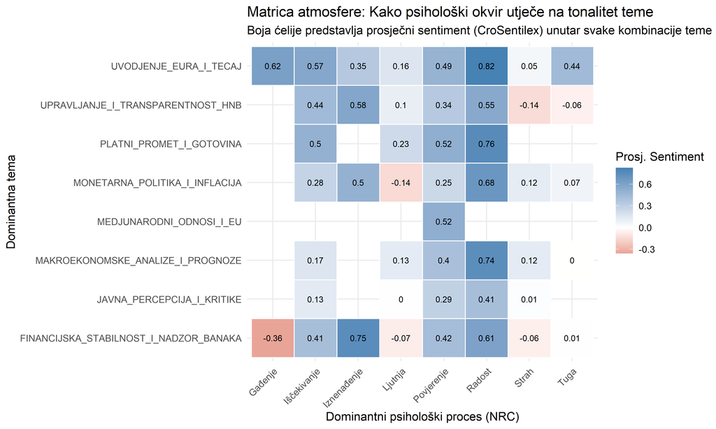

# II. Relativni indeks konflikta (RCI)

Standardna mjerenja ne uzimaju u obzir kontekst. Nije isto koristiti konfliktan jezik u članku o financijskoj krizi i u članku o rutinskim statističkim izvještajima. Relativni indeks konflikta (RCI) mjeri koliko je neki članak o HNB-u neočekivano agresivniji ili pomirljiviji od onoga što je uobičajeno za njegov medij i njegovu temu.

### Mapa medijskih strategija konflikta u financijskom izvještavanju

Sljedeći grafikon koristi RCI mjeru kako bi mapirao medije na temelju njihove strategije korištenja konfliktnog jezika u izvještavanju o HNB-u.Što je medij više desno, to je njegov ton prema HNB-u u prosjeku kritičniji. Što je medij više na grafikonu, to je njegov pristup HNB-u nepredvidljiviji.Veličina točke označava kupnu prisutnost medija u financijskom diskursu.

Ova mapa otkriva četiri različita modela financijskog novinarstva u hrvatskom digitalnom prostoru:

Gore desno - “Strateški kritičari HNB-a”: Mainstream ekonomski mediji koji doziraju kritiku HNB-a ovisno o ekonomskim okolnostima.

Dolje desno - “Dosljedni HNB skeptici”: Mediji s konstantno kritičkim stavom prema centralnoj banci, neovisno o situaciji.

Gore lijevo - “Pragmatični analitičari”: Tradicionalni financijski mediji s umjerenim tonom ali sposobnošću snažne kritike kada je potrebna.

Dolje lijevo - “Institucionalni podržavatelji”: Mediji koji dosljedno podržavaju HNB politike i rijetko koriste konfliktan jezik.

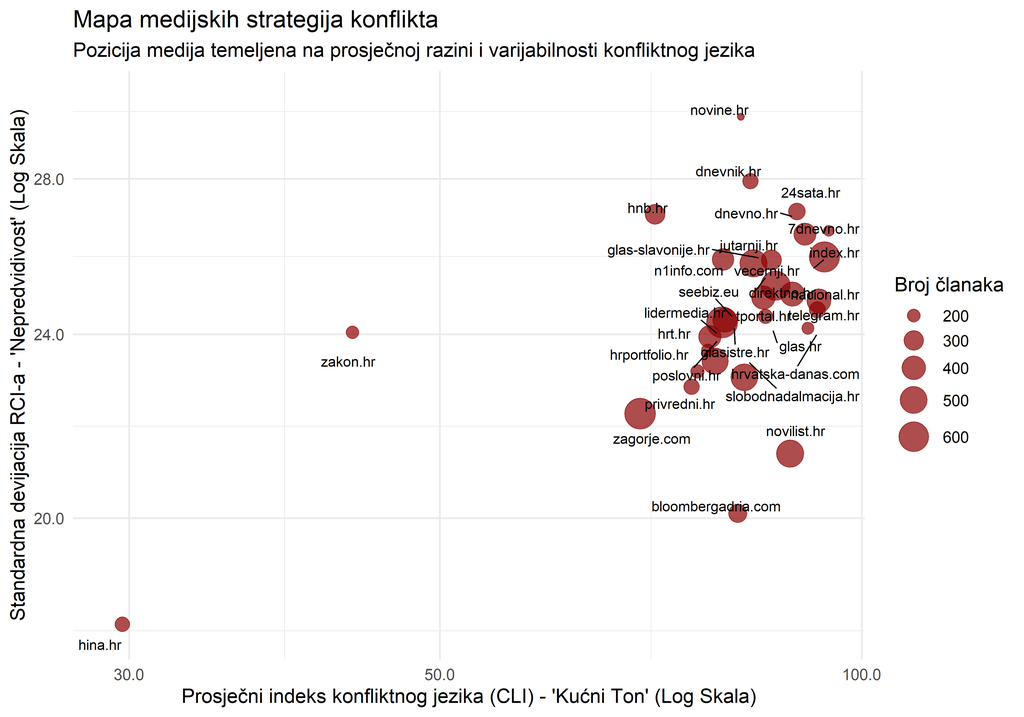

# III.Sinteza: Mreža narativne atmosfere

Konačno, spajamo sve u jednu vizualizaciju. Mreža povezanosti tema prikazuje kako se financijske teme spajaju u šire narativne okvire. Izgled svake veze otkriva atmosferu tih spojeva. Boja veze: prosječni tonalitet (Plavo = pozitivno prema HNB-u). Debljina veze: prosječni intenzitet konflikta (Deblje = konfliktnije).Prozirnost veze: pouzdanost veze, tj. broj članaka na kojima se temelji (Tamnije = pouzdanije).

Ova mreža otkriva strukturu hrvatskog financijskog digitalnog prostora:

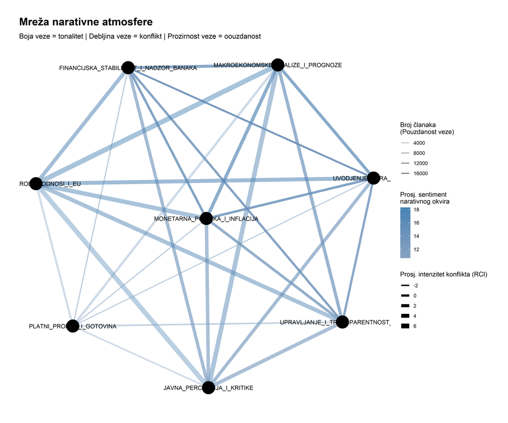

## Zaključak

Dubinska analiza atmosfere HNB digitalnog prostora u Hrvatskoj otkrila je sofisticiranu sliku koja nadilazi jednostavnu podjelu na “pozitivno” i “negativno” izvještavanje o centralnoj banci. Naši nalazi ukazuju na postojanje strateškog emocionalnog uokvirivanja financijskih tema i dubokih strukturnih obrazaca u javnom diskursu o monetarnoj politici.

Četiri modela financijskog novinarstva: Identificirali smo različite medijske strategije u pristupu HNB-u - od “strateških kritičara” koji doziraju kritiku do “institucionalnih podržavatelja” koji dosljedno podržavaju centralnu banku.

Ovi nalazi pokazuju da je za razumijevanje javnog mnijenja o HNB-u nužno analizirati ne samo što se govori, već kako se govori - koje se emocionalne strategije koriste za oblikovanje percepcije centralne banke u javnosti.